# Project Three: Predicting House Price With Regression

[figure not shown]

## Introduction

The [Kaggle House Price Competition](https://www.kaggle.com/c/house-prices-advanced-regression-techniques/overview) is a competition in which users try and get the best prediction of housing. Kaggle evaluates a submission on the "Root-Mean-Squared-Error (RMSE) between the logarithm of the predicted value and the logarithm of the observed sales price".

Both the training and testing sets are provided, with the training set used for predicting housing prices and the testing set used as a reference but without the price. Additionally, we will use this dataset to explore other insights, such as identifying which features contribute the most to price variations. Some key questions we seek to answer include:

- How "good" can we get the predicted price and identify good techniques for it?
- Can we build an accurate predictive model for housing prices using linear regression?
- How can we improve that model?

To predict a price, we'll use some form of regression. The first of the three experiments will focus on Linear Regression, and then in the next experiment, we'll use a ridge regression model to see if accuracy improves or not. Finally, in the last experiment, we'll perform some data manipulation and compare how those changes affected both models.

The dataset has ~80 different features with around 1,400+ total rows. The columns are displayed below and followed with a description:

| **Feature** | **Description** |
| --- | --- |
| SalePrice | The property's sale price in dollars **(Target Variable)** |
| MSSubClass | The building class (e.g., single-family detached, townhouse) |
| MSZoning | The general zoning classification (e.g., residential, commercial) |
| LotFrontage | Linear feet of street connected to the property |
| LotArea | Lot size in square feet |
| Street | Type of road access (e.g., paved, gravel) |
| Alley | Type of alley access (if any) |
| LotShape | General shape of the property |
| LandContour | Flatness of the property |
| Utilities | Type of utilities available (e.g., gas, electric, water) |
| LotConfig | Lot configuration (e.g., corner lot, inside lot) |
| LandSlope | Slope of the property |
| Neighborhood | Physical location within Ames city limits |
| Condition1 | Proximity to main roads or railroads |
| Condition2 | Proximity to main roads or railroads (if a second is present) |
| BldgType | Type of dwelling (e.g., single-family, duplex) |
| HouseStyle | Style of dwelling (e.g., one-story, two-story, split-level) |
| OverallQual | Overall material and finish quality (rated 1-10) |
| OverallCond | Overall condition rating of the house |
| YearBuilt | Original construction date of the house |
| YearRemodAdd | Year the house was remodeled or an addition was made |
| RoofStyle | Type of roof (e.g., gable, hip) |
| RoofMatl | Material of the roof |
| Exterior1st | Primary exterior covering of the house |
| Exterior2nd | Secondary exterior covering (if present) |
| MasVnrType | Masonry veneer type (e.g., brick, stone, none) |
| MasVnrArea | Masonry veneer area in square feet |
| ExterQual | Exterior material quality rating |
| ExterCond | Present condition of the material on the exterior |
| Foundation | Type of foundation (e.g., slab, crawl space, basement) |
| BsmtQual | Height of the basement |
| BsmtCond | General condition of the basement |
| GarageType | Location of the garage (e.g., attached, detached, built-in) |
| GarageCars | Size of the garage in terms of car capacity |
| GarageArea | Size of the garage in square feet |
| PavedDrive | Whether the driveway is paved |
| MoSold | Month the house was sold |
| YrSold | Year the house was sold |
| SaleType | Type of sale (e.g., normal, foreclosure, auction) |
| SaleCondition | Condition of sale (e.g., family sale, partial sale, normal sale) |

```python
#Imports
import numpy as np
import pandas as pd
import seaborn as sns
import matplotlib.pyplot as plt
import statsmodels.api as sm

from sklearn.model_selection import train_test_split
from sklearn.linear_model import LinearRegression
from sklearn.metrics import mean_squared_error
from sklearn.metrics import r2_score
from sklearn.linear_model import Ridge
```

```python
#dataset
df = pd.read_csv('train.csv')
df.head()
```

|  | Id | MSSubClass | MSZoning | LotFrontage | LotArea | Street | Alley | LotShape | LandContour | Utilities | ... | PoolArea | PoolQC | Fence | MiscFeature | MiscVal | MoSold | YrSold | SaleType | SaleCondition | SalePrice |
| --- | --- | --- | --- | --- | --- | --- | --- | --- | --- | --- | --- | --- | --- | --- | --- | --- | --- | --- | --- | --- | --- |
| 0 | 1 | 60 | RL | 65.0 | 8450 | Pave | NaN | Reg | Lvl | AllPub | ... | 0 | NaN | NaN | NaN | 0 | 2 | 2008 | WD | Normal | 208500 |
| 1 | 2 | 20 | RL | 80.0 | 9600 | Pave | NaN | Reg | Lvl | AllPub | ... | 0 | NaN | NaN | NaN | 0 | 5 | 2007 | WD | Normal | 181500 |
| 2 | 3 | 60 | RL | 68.0 | 11250 | Pave | NaN | IR1 | Lvl | AllPub | ... | 0 | NaN | NaN | NaN | 0 | 9 | 2008 | WD | Normal | 223500 |
| 3 | 4 | 70 | RL | 60.0 | 9550 | Pave | NaN | IR1 | Lvl | AllPub | ... | 0 | NaN | NaN | NaN | 0 | 2 | 2006 | WD | Abnorml | 140000 |
| 4 | 5 | 60 | RL | 84.0 | 14260 | Pave | NaN | IR1 | Lvl | AllPub | ... | 0 | NaN | NaN | NaN | 0 | 12 | 2008 | WD | Normal | 250000 |

5 rows × 81 columns

```python
df.shape
```

```
(1460, 81)
```

## Pre-processing

There are quite a few things I want to clean up from the dataset, so let's start with the the most complex one for this dataset, nulls.

### Handling nulls

```python
print(df.isnull().sum()[df.isnull().sum() > 0].sort_values())
```

```
Electrical         1
MasVnrArea         8
BsmtQual          37
BsmtCond          37
BsmtFinType1      37
BsmtExposure      38
BsmtFinType2      38
GarageCond        81
GarageQual        81
GarageFinish      81
GarageYrBlt       81
GarageType        81
LotFrontage      259
FireplaceQu      690
MasVnrType       872
Fence           1179
Alley           1369
MiscFeature     1406
PoolQC          1453
dtype: int64
```

```python
df = df.drop(['PoolQC', 'MiscFeature', 'Alley', 'Fence', 'MasVnrType', 'FireplaceQu'], axis=1)
df = df.dropna(subset=["Electrical"])
df.fillna(df.median(numeric_only=True), inplace=True)
```

```python
print(df.isnull().sum()[df.isnull().sum() > 0].sort_values())
```

```
BsmtQual        37
BsmtCond        37
BsmtFinType1    37
BsmtExposure    38
BsmtFinType2    38
GarageType      81
GarageFinish    81
GarageQual      81
GarageCond      81
dtype: int64
```

Okay we are left with the catergorical ones now. There are plent of ways to go about this but I'm lazy so i'll just fill them with "missing"

```python
df.fillna('missing', inplace=True)
print(df.isnull().sum()[df.isnull().sum() > 0].sort_values())
```

```
Series([], dtype: int64)
```

Cool, now we can work with all the data now. It's not super perfect as we'll see soon, but we'll come back to this.

### Duplicates

```python
df.duplicated().value_counts()
```

```
False    1459
Name: count, dtype: int64
```

No duplicates so let's move on.

### Dropping ID

We don't need the ID as it shouldn't affect the price at all and it would just be confusing to keep when graphing. Let's just drop it

```python
df = df.drop("Id", axis=1)
```

### One Hot Encoding with pd dummies

```python
df.dtypes.value_counts()
```

```
object     37
int64      34
float64     3
Name: count, dtype: int64
```

So we have around 37 objects which I assume are catergoirical. For now, let's just push them to dummies in an encoded df. We'll revisit this a bit later

```python
df_encoded = pd.get_dummies(df, drop_first=True)
```

```python
df_encoded.dtypes.value_counts()
```

```
bool       202
int64       34
float64      3
Name: count, dtype: int64
```

### Visualizing

Let's visualize some data to see if we can identify important pieces of data before we make a prediction. I'll be using a correlation heatmap to show the correlation between the different features. This might be bloated with a bunch of data, but we'll mainly be looking at the SalePrice feature.

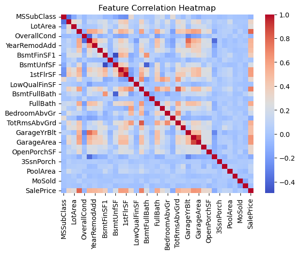

```python
df_numerical = df.select_dtypes(include=['number'])
corr = df_numerical.corr()
sns.heatmap(corr, cmap='coolwarm')
plt.title('Feature Correlation Heatmap')
plt.show()
```

## Experiment 1: Linear Regression

We're going to start with the first experiment, linear regression. Let's briefly review what linear regression does.

### What is Linear Regression?

Linear regression is a statistical method used to model the relationship between a dependent variable (SalesPrice) and one or more independent variables (The 80 other features). It assumes that there is a linear relationship between the dependent and independent variables. The goal is to find the best-fit line that minimizes the difference between the actual observed values and the predicted values, with that predicted value being continuous.

Linear Regression basic formula: $\hat{Y} = \theta_1 + \theta_2\mathbf{X}$

theta_1 is the intercept, theta_2 is the coefficient, and x is our feature, which equals our prediction.

You can add more features, which makes it a multiple linear regression. $\hat{Y} = \beta_1 + \beta_2\mathbf{X} + \beta_2\mathbf{X}2 + ... + \beta_n\mathbf{X}n$

The cost function is a way to identify the error in our prediction. The cost functions we'll be using are $MSE$, $RMSE$, and $R^2$.

$Cost Function(J) = \frac{1}{n}\sum_{n}^i (\hat{y}_i - y_i)^2$

Minimizing the cost function will give you your line of best fit.

### Initializing and prediciting values

```python
#Splitting the data
X = df_encoded.drop("SalePrice", axis=1)
y = df_encoded["SalePrice"]
X_train, X_test, y_train, y_test = train_test_split(X, y, test_size=0.2, random_state=42)

lr = LinearRegression()
lr.fit(X_train, y_train)
y_pred = lr.predict(X_test)
```

### Evaluation

```python
# Mean Squared Error (MSE)
mse = mean_squared_error(y_test, y_pred)
print("MSE:", mse)

# Root Mean Squared Error (RMSE)
rmse = np.sqrt(mse)
print("RMSE:", rmse)

# R-squared (R²)
r2 = r2_score(y_test, y_pred)
print("R²:", r2)
```

```
MSE: 2716867495.489335
RMSE: 52123.57907405568
R²: 0.4970244901778321
```

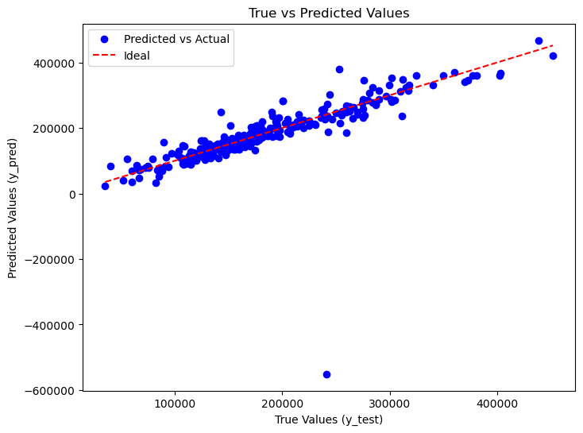

```python
# Plotting the true values vs. predicted values
plt.figure(figsize=(8, 6))
plt.scatter(y_test, y_pred, color='blue', label='Predicted vs Actual')
plt.plot([min(y_test), max(y_test)], [min(y_test), max(y_test)], color='red', linestyle='--', label='Ideal')
plt.xlabel('True Values (y_test)')
plt.ylabel('Predicted Values (y_pred)')
plt.title('True vs Predicted Values')
plt.legend()
plt.show()
```

Not super bad, but could be **way** better. A very weird prediction in the middle as well. We'll have to do some more work on this data if we want this model to work out.

### Experiment 2: Other Linear Regression + Ridge Regression

First, let's just start with statsmodel's OLS Linear Regression module. It'll allow us to get a summary of the data. In experiment 3, it will be helpful for identifying some facts about how are features relate to the SalesPrice..

```python
# Redoing X and y
df_encoded = df_encoded.select_dtypes(include=['number'])
X = df_encoded.drop("SalePrice", axis=1)
y = df_encoded["SalePrice"]
X_train, X_test, y_train, y_test = train_test_split(X, y, test_size=0.2, random_state=42)

#MLR
X_train_sm = sm.add_constant(X_train)
mlr_model = sm.OLS(y_train, X_train_sm).fit()
print(mlr_model.summary())
```

```
                            OLS Regression Results
==============================================================================
Dep. Variable:              SalePrice   R-squared:                       0.801
Model:                            OLS   Adj. R-squared:                  0.795
Method:                 Least Squares   F-statistic:                     133.8
Date:                Mon, 31 Mar 2025   Prob (F-statistic):               0.00
Time:                        22:27:04   Log-Likelihood:                -13902.
No. Observations:                1167   AIC:                         2.787e+04
Df Residuals:                    1132   BIC:                         2.805e+04
Df Model:                          34
Covariance Type:            nonrobust
=================================================================================
                    coef    std err          t      P>|t|      [0.025      0.975]
---------------------------------------------------------------------------------
const          6.581e+05   1.67e+06      0.393      0.694   -2.62e+06    3.94e+06
MSSubClass     -188.5228     32.852     -5.738      0.000    -252.981    -124.065
LotFrontage     -97.9323     66.447     -1.474      0.141    -228.305      32.440
LotArea           0.3652      0.118      3.105      0.002       0.134       0.596
OverallQual    1.729e+04   1389.574     12.444      0.000    1.46e+04       2e+04
OverallCond    4395.1212   1248.799      3.519      0.000    1944.901    6845.341
YearBuilt       246.4064     79.207      3.111      0.002      90.996     401.816
YearRemodAdd    146.8789     81.734      1.797      0.073     -13.489     307.246
MasVnrArea       32.6496      7.514      4.345      0.000      17.906      47.393
BsmtFinSF1       10.6407      3.000      3.547      0.000       4.754      16.527
BsmtFinSF2       -3.5475      5.575     -0.636      0.525     -14.487       7.392
BsmtUnfSF        -0.4652      2.891     -0.161      0.872      -6.137       5.207
TotalBsmtSF       6.6280      4.199      1.578      0.115      -1.611      14.867
1stFlrSF         12.4720      7.408      1.684      0.093      -2.062      27.007
2ndFlrSF          9.2367      6.779      1.363      0.173      -4.065      22.538
LowQualFinSF     15.6763     17.840      0.879      0.380     -19.327      50.680
GrLivArea        37.3851      6.813      5.488      0.000      24.018      50.752
BsmtFullBath   1.029e+04   3070.886      3.351      0.001    4265.742    1.63e+04
BsmtHalfBath   4442.0917   5099.651      0.871      0.384   -5563.739    1.44e+04
FullBath       5095.3088   3370.623      1.512      0.131   -1518.062    1.17e+04
HalfBath      -1622.4208   3085.540     -0.526      0.599   -7676.440    4431.599
BedroomAbvGr  -1.176e+04   2059.735     -5.711      0.000   -1.58e+04   -7722.347
KitchenAbvGr   -1.52e+04   5974.666     -2.545      0.011   -2.69e+04   -3480.045
TotRmsAbvGrd   6710.7699   1467.007      4.574      0.000    3832.412    9589.127
Fireplaces     4502.7858   2094.152      2.150      0.032     393.929    8611.642
GarageYrBlt     132.5335     80.597      1.644      0.100     -25.602     290.669
GarageCars     1.149e+04   3384.432      3.396      0.001    4853.811    1.81e+04
GarageArea       -3.9734     11.850     -0.335      0.737     -27.224      19.278
WoodDeckSF       21.9861      9.496      2.315      0.021       3.355      40.617
OpenPorchSF      -6.0158     17.256     -0.349      0.727     -39.872      27.841
EnclosedPorch     9.3865     19.848      0.473      0.636     -29.556      48.329
3SsnPorch        25.7117     35.332      0.728      0.467     -43.611      95.034
ScreenPorch      48.7829     20.016      2.437      0.015       9.511      88.055
PoolArea        -48.3833     31.662     -1.528      0.127    -110.506      13.739
MiscVal          -0.5323      1.967     -0.271      0.787      -4.392       3.328
MoSold         -185.4929    408.723     -0.454      0.650    -987.433     616.447
YrSold         -871.9089    832.455     -1.047      0.295   -2505.237     761.419
==============================================================================
Omnibus:                      454.963   Durbin-Watson:                   1.972
Prob(Omnibus):                  0.000   Jarque-Bera (JB):            71722.098
Skew:                          -0.674   Prob(JB):                         0.00
Kurtosis:                      41.382   Cond. No.                     1.31e+16
==============================================================================

Notes:
[1] Standard Errors assume that the covariance matrix of the errors is correctly specified.
[2] The smallest eigenvalue is 1.54e-21. This might indicate that there are
strong multicollinearity problems or that the design matrix is singular.
```

### Evaluation

```python
# Get predictions for training data
y_train_pred = mlr_model.predict(X_train_sm)

# Calculate metrics
mse_train = mlr_model.mse_total  # Mean Squared Error (MSE)
rmse_train = np.sqrt(mse_train)  # Root Mean Squared Error (RMSE)
r2_train = mlr_model.rsquared     # R-squared (from model summary)

print(f"Training MSE: {mse_train:.2f}")
print(f"Training RMSE: {rmse_train:.2f}")
print(f"Training R²: {r2_train:.4f}")
```

```
Training MSE: 6544133366.64
Training RMSE: 80895.82
Training R²: 0.8008
```

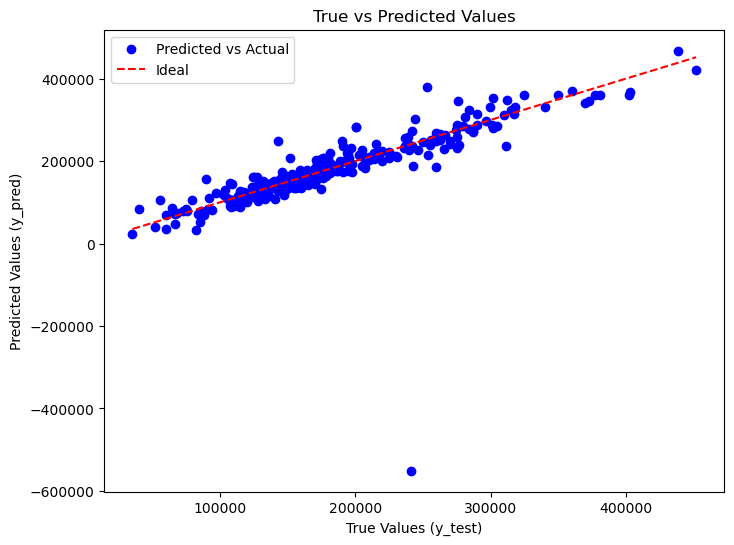

```python
# Plotting the true values vs. predicted values
plt.figure(figsize=(8, 6))
plt.scatter(y_test, y_pred, color='blue', label='Predicted vs Actual')
plt.plot([min(y_test), max(y_test)], [min(y_test), max(y_test)], color='red', linestyle='--', label='Ideal')
plt.xlabel('True Values (y_test)')
plt.ylabel('Predicted Values (y_pred)')
plt.title('True vs Predicted Values')
plt.legend()
plt.show()
```

| Good Predictors | Bad Predictors |
| --- | --- |
| MSSubClass | LotFrontage |
| LotArea | YearRemodAdd |
| OverallQual | BsmtFinSF2 |
| OverallCond | GarageArea |
| YearBuilt | OpenPorchSF |
| MasVnrArea | YrSold |
| BsmtFinSF1 | MiscVal |
| GrLivArea | MoSold |
| BsmtFullBath |  |
| TotRmsAbvGrd |  |
| Fireplaces |  |
| GarageCars |  |
| WoodDeckSF |  |

We'll look more into this in Experiment 3, but let's just look at ridge regression first.

## Ridge Regression

Since we found a quite few correlated values, I want to check to see if ridge regression would be better.

**Ridge regression** is a linear regression method that addresses multicollinearity (high correlation between predictor variables) by adding a penalty term to the cost function, shrinking coefficients toward zero without eliminating any and improving model stability and generalization.

It's possible that this model isn't needed since it's usually for accounting *independent* variables correlation, and as the features of the house are dependent on the price, it'll probably not be super effective. But it'll be nice to see if it does anything.

```python
ridge_model = Ridge(alpha=1.0)
ridge_model.fit(X_train, y_train)
y_pred = ridge_model.predict(X_test)
```

### Evaluation

```python
# Mean Squared Error (MSE)
mse = mean_squared_error(y_test, y_pred)
print("MSE:", mse)

# Root Mean Squared Error (RMSE)
rmse = np.sqrt(mse)
print("RMSE:", rmse)

# R-squared (R²)
r2 = r2_score(y_test, y_pred)
print("R²:", r2)
```

```
MSE: 728016217.1672391
RMSE: 26981.77564889381
R²: 0.865221867243641
```

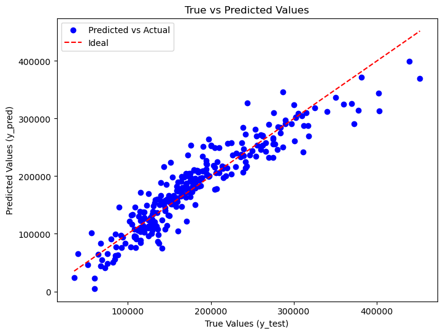

```python
# Plotting the true values vs. predicted values
plt.figure(figsize=(8, 6))
plt.scatter(y_test, y_pred, color='blue', label='Predicted vs Actual')
plt.plot([min(y_test), max(y_test)], [min(y_test), max(y_test)], color='red', linestyle='--', label='Ideal')
plt.xlabel('True Values (y_test)')
plt.ylabel('Predicted Values (y_pred)')
plt.title('True vs Predicted Values')
plt.legend()
plt.show()
```

This model **does** preform the best. I'd believe since we have so many features, ridge regression probably is able to "fix" all the weird corrolation features that are independent of the price. I'd expect to see this change as we modify the data.

## Experiment 3: Modifying the data

Let's modify some of the data now that we have some more insight. First, let's get rid of all the "bad" columns we identified earlier. Then I want to try and manually sift through the whole dataset and remove outliers.

```python
good_columns = [
    "MSSubClass", "LotArea", "OverallQual", "OverallCond", "YearBuilt",
    "MasVnrArea", "BsmtFinSF1", "GrLivArea", "BsmtFullBath", "TotRmsAbvGrd",
    "Fireplaces", "GarageCars", "WoodDeckSF", "ScreenPorch", "SalePrice"
]

df_modified = df[good_columns]
```

### Outliers

I didn't mess with outliers before, mostly because we were dealing with so many features, so let's see what they look like now. There is going to be a lot of graphs we'll be looking at so don't get overwhelmed.

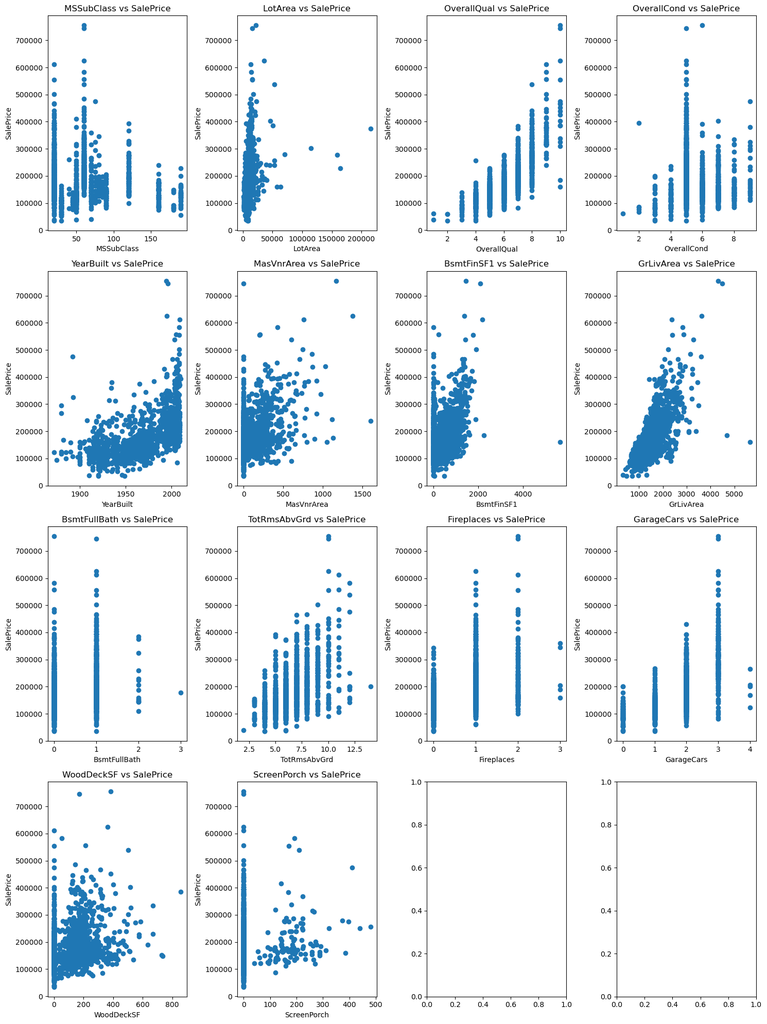

```python
numeric_cols = df_modified.select_dtypes(include=['number']).columns.tolist()
numeric_cols = [col for col in numeric_cols if col != 'SalePrice']

n_cols = 4
n_rows = (len(numeric_cols) + n_cols - 1) // n_cols

fig, axes = plt.subplots(n_rows, n_cols, figsize=(15, 5*n_rows))
axes = axes.flatten()

for i, col in enumerate(numeric_cols):
    axes[i].scatter(x=df[col], y=df['SalePrice'])
    axes[i].set_xlabel(col)
    axes[i].set_ylabel('SalePrice')
    axes[i].set_title(f'{col} vs SalePrice')

plt.tight_layout()
plt.show()
```

We have found a few outliers from the graphs, and I would like the get rid of them. I'm going to try using a z-score method for getting rid of them and hopefully that improve the model's predictions.

```python
from scipy.stats import zscore

# Calculate Z-Scores for numeric columns
z_scores = df_modified[good_columns].apply(zscore)

# Keep rows where all Z-Scores are within ±3
df_clean = df_modified[(z_scores.abs() < 3).all(axis=1)]
```

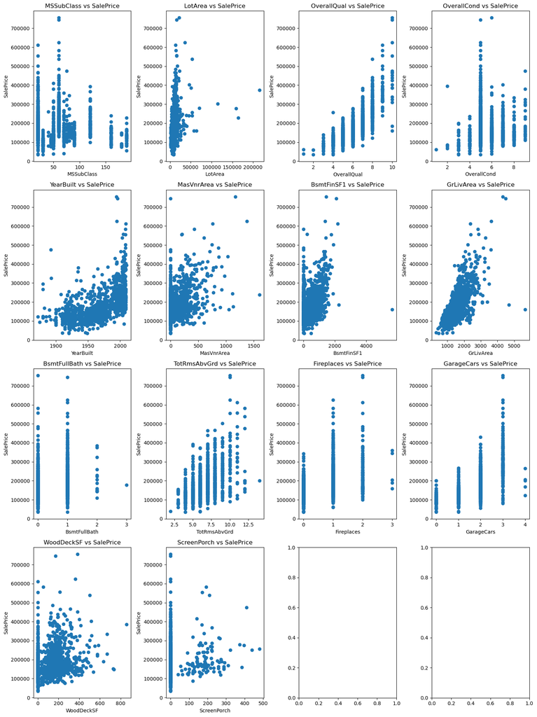

```python
numeric_cols = df_clean.select_dtypes(include=['number']).columns.tolist()
numeric_cols = [col for col in numeric_cols if col != 'SalePrice']

n_cols = 4
n_rows = (len(numeric_cols) + n_cols - 1) // n_cols

fig, axes = plt.subplots(n_rows, n_cols, figsize=(15, 5*n_rows))
axes = axes.flatten()

for i, col in enumerate(numeric_cols):
    axes[i].scatter(x=df[col], y=df['SalePrice'])
    axes[i].set_xlabel(col)
    axes[i].set_ylabel('SalePrice')
    axes[i].set_title(f'{col} vs SalePrice')

plt.tight_layout()
plt.show()
```

```python
df_encoded = pd.get_dummies(df_clean, drop_first=True)
```

Alright, moment of truth.

### Linear Regression part 2

```python
X = df_encoded.drop("SalePrice", axis=1)
y = df_encoded["SalePrice"]
X_train, X_test, y_train, y_test = train_test_split(X, y, test_size=0.2, random_state=42)

lr = LinearRegression()
lr.fit(X_train, y_train)
y_pred = lr.predict(X_test)
```

### Evaluation

```python
# Mean Squared Error (MSE)
mse = mean_squared_error(y_test, y_pred)
print("MSE:", mse)

# Root Mean Squared Error (RMSE)
rmse = np.sqrt(mse)
print("RMSE:", rmse)

# R-squared (R²)
r2 = r2_score(y_test, y_pred)
print("R²:", r2)
```

```
MSE: 538143702.8926393
RMSE: 23197.924538471954
R²: 0.8802107041510574
```

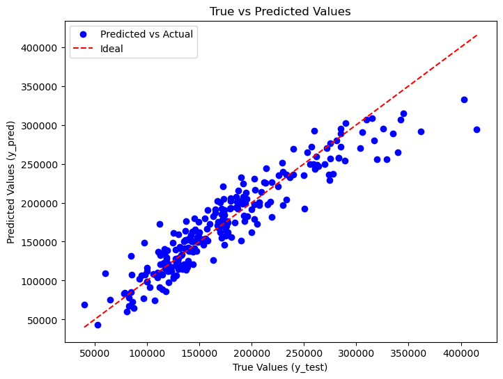

```python
# Plotting the true values vs. predicted values
plt.figure(figsize=(8, 6))
plt.scatter(y_test, y_pred, color='blue', label='Predicted vs Actual')
plt.plot([min(y_test), max(y_test)], [min(y_test), max(y_test)], color='red', linestyle='--', label='Ideal')
plt.xlabel('True Values (y_test)')
plt.ylabel('Predicted Values (y_pred)')
plt.title('True vs Predicted Values')
plt.legend()
plt.show()
```

Our original model is doing much better! As always, it could be improved upon, but I'm happy to see a great improvement. Let's see how the statsmodel would look with this refined data.

```python
# Redoing X and y
X = df_encoded.drop("SalePrice", axis=1)
y = df_encoded["SalePrice"]
X_train, X_test, y_train, y_test = train_test_split(X, y, test_size=0.2, random_state=42)

#MLR
X_train_sm = sm.add_constant(X_train)
mlr_model = sm.OLS(y_train, X_train_sm).fit()
```

```python
# Get predictions for sm.OLS
y_train_pred = mlr_model.predict(X_train_sm)

# Calculate metrics
mse_train = mlr_model.mse_total
rmse_train = np.sqrt(mse_train)
r2_train = mlr_model.rsquared

print(f"Training MSE: {mse_train}")
print(f"Training RMSE: {rmse_train}")
print(f"Training R²: {r2_train}")
```

```
Training MSE: 3933986470.889766
Training RMSE: 62721.49927169922
Training R²: 0.8459657298107548
```

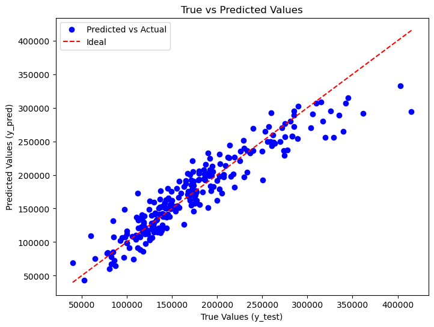

```python
# Plotting the true values vs. predicted values
plt.figure(figsize=(8, 6))
plt.scatter(y_test, y_pred, color='blue', label='Predicted vs Actual')
plt.plot([min(y_test), max(y_test)], [min(y_test), max(y_test)], color='red', linestyle='--', label='Ideal')
plt.xlabel('True Values (y_test)')
plt.ylabel('Predicted Values (y_pred)')
plt.title('True vs Predicted Values')
plt.legend()
plt.show()
```

### Ridge Regression part 2

```python
# Redoing X and y
X = df_encoded.drop("SalePrice", axis=1)
y = df_encoded["SalePrice"]
X_train, X_test, y_train, y_test = train_test_split(X, y, test_size=0.2, random_state=42)

ridge_model = Ridge(alpha=1.0)
ridge_model.fit(X_train, y_train)
y_pred = ridge_model.predict(X_test)
```

### Evaluation

```python
# Mean Squared Error (MSE)
mse = mean_squared_error(y_test, y_pred)
print("MSE:", mse)

# Root Mean Squared Error (RMSE)
rmse = np.sqrt(mse)
print("RMSE:", rmse)

# R-squared (R²)
r2 = r2_score(y_test, y_pred)
print("R²:", r2)
```

```
MSE: 538255762.0279462
RMSE: 23200.33969639122
R²: 0.8801857600983077
```

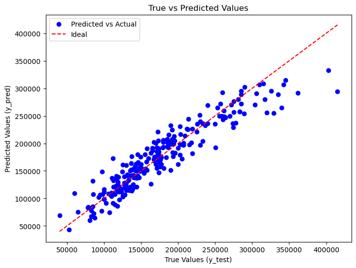

```python
# Plotting the true values vs. predicted values
plt.figure(figsize=(8, 6))
plt.scatter(y_test, y_pred, color='blue', label='Predicted vs Actual')
plt.plot([min(y_test), max(y_test)], [min(y_test), max(y_test)], color='red', linestyle='--', label='Ideal')
plt.xlabel('True Values (y_test)')
plt.ylabel('Predicted Values (y_pred)')
plt.title('True vs Predicted Values')
plt.legend()
plt.show()
```

## Impact

As we have found a decent model and way to predict new housing values, let's discuss what that means. Being able to predict what a house price is allows consumers to be more informed about what a house's price might look like given certain features. These price predictions could speed up the process of selling and buying a house since there is some common ground for negotiation.

However, we have to keep in mind that this dataset might implicate some bias towards housing from historical data. Data, especially from the 1960s-1990s, might be undervalued because of racial or socio-economic factors, which would be unfair for the seller. There is also a privacy concern with maintaining this dataset for the future as it needs to maintain anonymity and volunteer the data. Lastly, this dataset could be privy to real estate agencies that might try and artificially raise their rates by overvaluing and "buying/loaning" their property.

## Conclusion

As for how this project went, it was way more diffcult than I anticipated. I ran into quite a lot of errors that I didn't fully understand how to solve as it needed attention to detail, which, with so many features, felt overwhelming. Starting with the easy preprocessing steps (nulls, dupes, etc.) really helped with getting something down, even if I wasn't 100% sure I was doing it effectively.

All and all, I'm pretty happy with this project, especially being able to improve results from where we started. I'm hopeful I can follow in similar suite in the cluster project next.

## References

- [Kaggle House Price Competition](https://www.kaggle.com/c/house-prices-advanced-regression-techniques/overview)